[figure not shown]

[figure not shown]

[figure not shown]

[figure not shown]

[figure not shown]

[figure not shown]

# NDEC

JEFF-3.3

562

### **Access Files Individually**

| Z | A | State | File | psyche | checkr | njoy | fizcon | inter | endf2c | relable | prepro | ENDF-6 | ACE |
| --- | --- | --- | --- | --- | --- | --- | --- | --- | --- | --- | --- | --- | --- |
| 2 | 3 | 0 | 7071.endf | 0 msg | 0 msg | 3 warn | 1 err | 0 msg | 0 msg | 0 msg | 0 msg |  |  |
| 44 | 98 | 0 | ru98.hendf | 0 msg | 5 warn / 25 err | 2 warn / 1 err | 8 err | 0 msg | 0 msg | 0 msg | 0 msg |  | (missing) |

### **List of modified files since previous release JEFF-3.2**

| Z | Isotope | Updated? | Half-Life | Map |
| --- | --- | --- | --- | --- |
| 1 | H-1-g | True | stable |  |
| 1 | H-2-g | True | stable |  |
| 1 | H-3-g | True | 12.3 y |  |
| 10 | Ne-20-g | True | stable |  |
| 10 | Ne-21-g | True | stable |  |
| 10 | Ne-22-g | True | stable |  |
| 100 | Fm-255-g | True | 20.1 h |  |
| 11 | Na-22-g | True | 2.6 y |  |
| 11 | Na-23-g | True | stable |  |
| 12 | Mg-24-g | True | stable |  |

[output cut: 552 more lines]

# MF31

### Description

MF 31 : Data covariances for nubar.

Showing JEFF-3.3 distribution of data for MF 31, with matching origins for each MF/MT section.

### Evaluations with MF 31 in JEFF-3.3

[interactive chart not shown]

### MF 31 sections in JEFF-3.3

136

### List of JEFF-3.3 isotopes containing MF 31 data

|  | Z | SYMAM | MT | Type of data | Origin |
| --- | --- | --- | --- | --- | --- |
| 1 | 89 | Ac-225-g | 452 | number of neutrons per fission | JENDL-4.0 |
| 2 | 89 | Ac-226-g | 452 | number of neutrons per fission | JENDL-4.0 |
| 3 | 89 | Ac-227-g | 452 | number of neutrons per fission | JENDL-4.0 |
| 4 | 89 | Ac-225-g | 455 | delayed neutron data | JENDL-4.0 |
| 5 | 89 | Ac-226-g | 455 | delayed neutron data | JENDL-4.0 |
| 6 | 89 | Ac-227-g | 455 | delayed neutron data | JENDL-4.0 |
| 7 | 89 | Ac-225-g | 456 | number of prompt neutrons per fission | JENDL-4.0 |
| 8 | 89 | Ac-226-g | 456 | number of prompt neutrons per fission | JENDL-4.0 |
| 9 | 89 | Ac-227-g | 456 | number of prompt neutrons per fission | JENDL-4.0 |
| 10 | 95 | Am-243-g | 452 | number of neutrons per fission | JENDL-4.0 |

[output cut: 126 more lines]

### Origin histogram of MF 31 sections found in JEFF-3.3

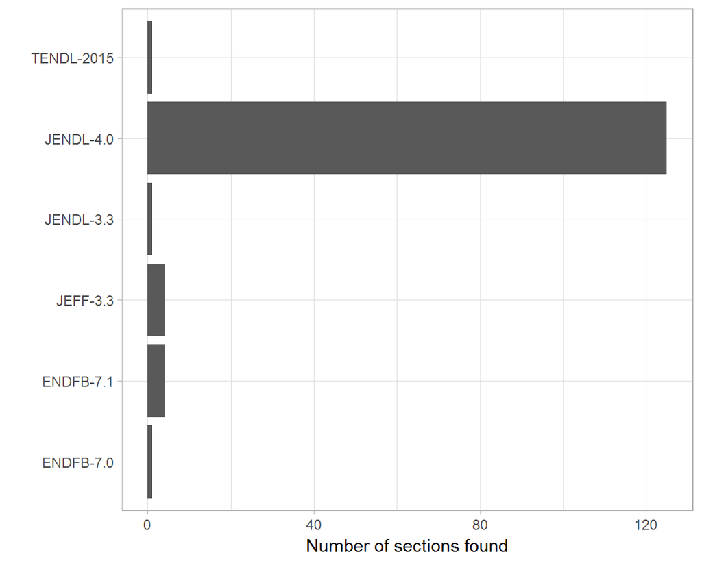

# MF32

### Description

MF 32 : Data covariances for resonance parameters.

Showing JEFF-3.3 distribution of data for MF 32, with matching origins for each MF/MT section.

### Evaluations with MF 32 in JEFF-3.3

[interactive chart not shown]

### MF 32 sections in JEFF-3.3

352

### List of JEFF-3.3 isotopes containing MF 32 data

|  | Z | SYMAM | MT | Type of data | Origin |
| --- | --- | --- | --- | --- | --- |
| 1 | 47 | Ag-106-m | 151 |  | TENDL-2015 |
| 2 | 47 | Ag-107-g | 151 |  | TENDL-2015 |
| 3 | 47 | Ag-108-g | 151 |  | JEFF-3.3 |
| 4 | 47 | Ag-110-g | 151 |  | JEFF-3.3 |
| 5 | 47 | Ag-111-g | 151 |  | JEFF-3.3 |
| 6 | 13 | Al-26-g | 151 |  | JEFF-3.3 |
| 7 | 13 | Al-27-g | 151 |  | JEFF-3.3 |
| 8 | 95 | Am-241-g | 151 |  | JEFF-3.2 |
| 9 | 95 | Am-243-g | 151 |  | JENDL-4.0 |
| 10 | 18 | Ar-36-g | 151 |  | JEFF-3.3 |

[output cut: 342 more lines]

### Origin histogram of MF 32 sections found in JEFF-3.3

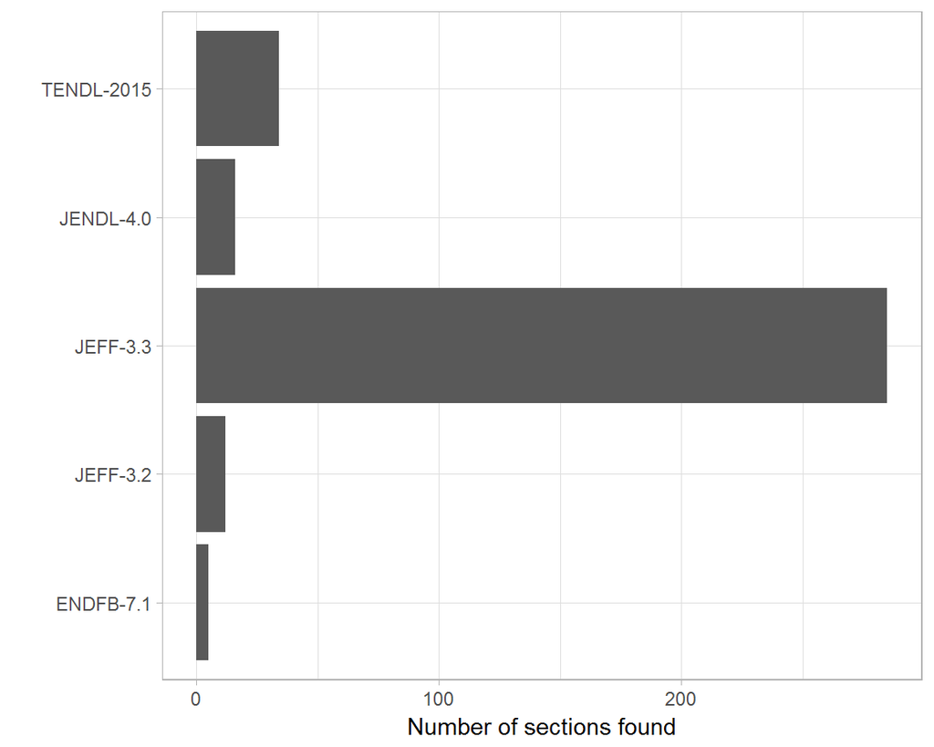

# MF33

### Description

MF 33 : Data covariances for reaction cross sections.

Showing JEFF-3.3 distribution of data for MF 33, with matching origins for each MF/MT section.

### Evaluations with MF 33 in JEFF-3.3

[interactive chart not shown]

### MF 33 sections in JEFF-3.3

12205

### List of JEFF-3.3 isotopes containing MF 33 data

|  | Z | SYMAM | MT | Type of data | Origin |
| --- | --- | --- | --- | --- | --- |
| 1 | 89 | Ac-225-g | 1 | total | JENDL-4.0 |
| 2 | 89 | Ac-226-g | 1 | total | JENDL-4.0 |
| 3 | 89 | Ac-227-g | 1 | total | JENDL-4.0 |
| 4 | 89 | Ac-225-g | 2 | elastic scattering | JENDL-4.0 |
| 5 | 89 | Ac-226-g | 2 | elastic scattering | JENDL-4.0 |
| 6 | 89 | Ac-227-g | 2 | elastic scattering | JENDL-4.0 |
| 7 | 89 | Ac-225-g | 4 | total inelastic scattering | JENDL-4.0 |
| 8 | 89 | Ac-226-g | 4 | total inelastic scattering | JENDL-4.0 |
| 9 | 89 | Ac-227-g | 4 | total inelastic scattering | JENDL-4.0 |
| 10 | 89 | Ac-225-g | 16 | (n,2n) | JENDL-4.0 |

[output cut: 12195 more lines]

### Origin histogram of MF 33 sections found in JEFF-3.3

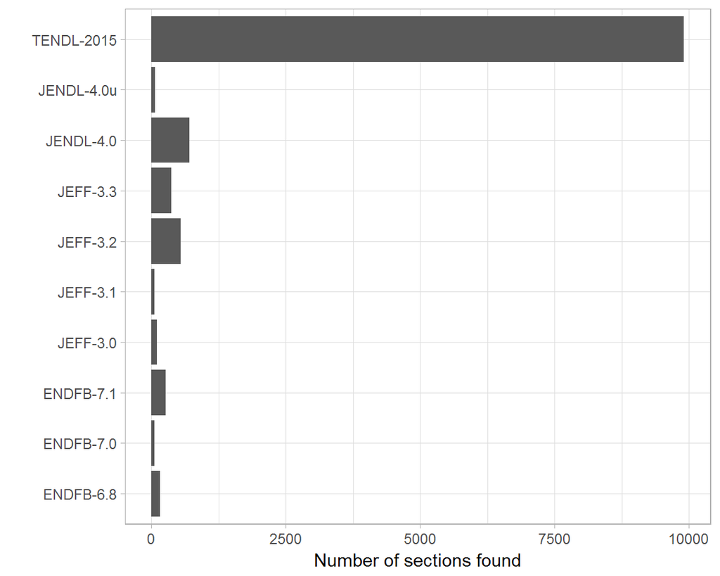

# MF34

### Description

MF 34 : Data covariances for angular distributions.

Showing JEFF-3.3 distribution of data for MF 34, with matching origins for each MF/MT section.

### Evaluations with MF 34 in JEFF-3.3

[interactive chart not shown]

### MF 34 sections in JEFF-3.3

361

### List of JEFF-3.3 isotopes containing MF 34 data

|  | Z | SYMAM | MT | Type of data | Origin |
| --- | --- | --- | --- | --- | --- |
| 1 | 89 | Ac-225-g | 2 | elastic scattering | JENDL-4.0 |
| 2 | 89 | Ac-226-g | 2 | elastic scattering | JENDL-4.0 |
| 3 | 89 | Ac-227-g | 2 | elastic scattering | JENDL-4.0 |
| 4 | 47 | Ag-106-m | 2 | elastic scattering | TENDL-2015 |
| 5 | 47 | Ag-107-g | 2 | elastic scattering | TENDL-2015 |
| 6 | 47 | Ag-108-g | 2 | elastic scattering | TENDL-2015 |
| 7 | 47 | Ag-110-g | 2 | elastic scattering | TENDL-2015 |
| 8 | 47 | Ag-111-g | 2 | elastic scattering | TENDL-2015 |
| 9 | 13 | Al-26-g | 2 | elastic scattering | TENDL-2015 |
| 10 | 95 | Am-243-g | 2 | elastic scattering | JENDL-4.0 |

[output cut: 351 more lines]

### Origin histogram of MF 34 sections found in JEFF-3.3

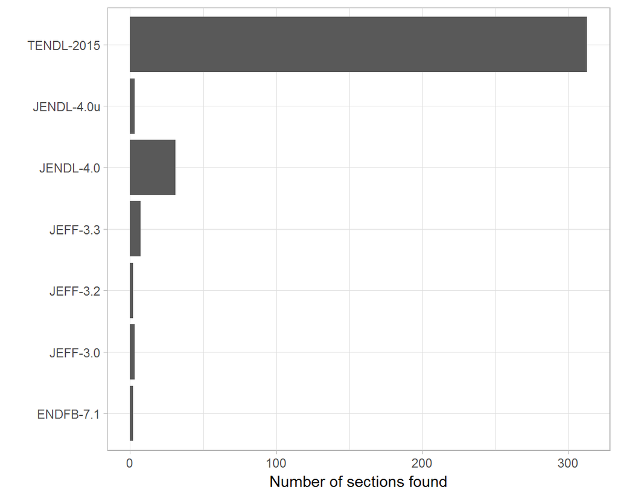

# MF35

### Description

MF 35 : Data covariances for energy distributions.

Showing JEFF-3.3 distribution of data for MF 35, with matching origins for each MF/MT section.

### Evaluations with MF 35 in JEFF-3.3

[interactive chart not shown]

### MF 35 sections in JEFF-3.3

36

### List of JEFF-3.3 isotopes containing MF 35 data

|  | Z | SYMAM | MT | Type of data | Origin |
| --- | --- | --- | --- | --- | --- |
| 1 | 89 | Ac-225-g | 18 | total fission | JENDL-4.0 |
| 2 | 89 | Ac-226-g | 18 | total fission | JENDL-4.0 |
| 3 | 89 | Ac-227-g | 18 | total fission | JENDL-4.0 |
| 4 | 95 | Am-243-g | 18 | total fission | JENDL-4.0 |
| 5 | 95 | Am-244-g | 18 | total fission | JENDL-4.0 |
| 6 | 95 | Am-244-m | 18 | total fission | JENDL-4.0 |
| 7 | 97 | Bk-247-g | 18 | total fission | JENDL-4.0 |
| 8 | 97 | Bk-249-g | 18 | total fission | JENDL-4.0 |
| 9 | 97 | Bk-250-g | 18 | total fission | JENDL-4.0 |
| 10 | 98 | Cf-249-g | 18 | total fission | JENDL-4.0 |

[output cut: 26 more lines]

### Origin histogram of MF 35 sections found in JEFF-3.3

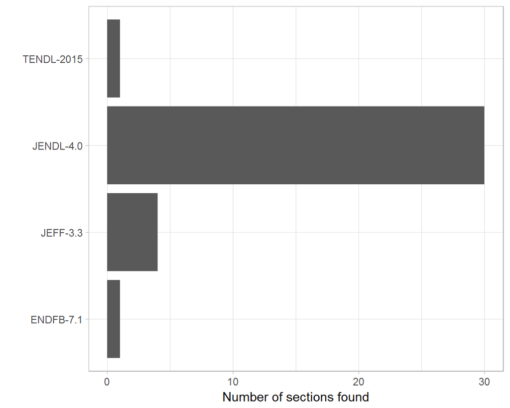

# MF40

### Description

MF 40 : Data covariances for radionuclide production cross sections.

Showing JEFF-3.3 distribution of data for MF 40, with matching origins for each MF/MT section.

### Evaluations with MF 40 in JEFF-3.3

[interactive chart not shown]

### MF 40 sections in JEFF-3.3

1946

### List of JEFF-3.3 isotopes containing MF 40 data

|  | Z | SYMAM | MT | Type of data | Origin |
| --- | --- | --- | --- | --- | --- |
| 1 | 47 | Ag-107-g | 4 | total inelastic scattering | TENDL-2015 |
| 2 | 47 | Ag-108-g | 4 | total inelastic scattering | TENDL-2015 |
| 3 | 47 | Ag-110-g | 4 | total inelastic scattering | TENDL-2015 |
| 4 | 47 | Ag-111-g | 4 | total inelastic scattering | TENDL-2015 |
| 5 | 47 | Ag-110-g | 11 | (n,2nd) | TENDL-2015 |
| 6 | 47 | Ag-106-m | 16 | (n,2n) | TENDL-2015 |
| 7 | 47 | Ag-107-g | 16 | (n,2n) | TENDL-2015 |
| 8 | 47 | Ag-108-g | 16 | (n,2n) | TENDL-2015 |
| 9 | 47 | Ag-110-g | 16 | (n,2n) | TENDL-2015 |
| 10 | 47 | Ag-111-g | 16 | (n,2n) | TENDL-2015 |

[output cut: 1936 more lines]

### Origin histogram of MF 40 sections found in JEFF-3.3

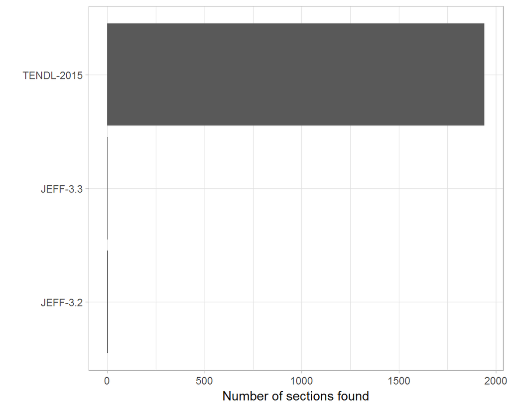